# Loan Data from Prosper Exploration

Lucas Vilas Boas de Lima

### Table of Contents:

1. Data Assesment
2. Data Cleaning
3. Further Wrangling
4. Univariate Exploration
5. Bivariate Exploration
6. Multivariate Exploration
7. Multi Variable Regression Model
8. Conclusion

## Introduction

Prosper Marketplace, Inc. is a San Francisco, California-based company in the peer-to-peer lending industry. Prosper Funding LLC, one of its subsidiaries, operates Prosper.com, a website where individuals can either invest in personal loans or request to borrow money. (soure: [Wikipedia](https://en.wikipedia.org/wiki/Prosper_Marketplace) )

Today we shall take a look at a Dataset with information for over 100K loans processed by Prosper ranging from 2005 to 2014.

## Loading Libraries and Data

```python
import numpy as np
import pandas as pd
import matplotlib.pyplot as plt
import seaborn as sb


%matplotlib inline
```

```python
from sklearn import linear_model
import statsmodels.api as sm
```

```python
loan_data = pd.read_csv('prosperLoanData.csv')
```

### Dataset Structure, Main features and possible impact on investigation

Our dataset comes from a csv file with 113937 rows and 81 columns. Some are not so important for us, such as ListingKey and ListingNumber, but some are of vital importance to answer interesting questions, such as how can Credit Grade and IncomeRange affect BorrowerAPR.

## Visual and Progmatic Data Assessment

```python
loan_data.head()
```

|  | ListingKey | ListingNumber | ListingCreationDate | CreditGrade | Term | LoanStatus | ClosedDate | BorrowerAPR | BorrowerRate | LenderYield | ... | LP_ServiceFees | LP_CollectionFees | LP_GrossPrincipalLoss | LP_NetPrincipalLoss | LP_NonPrincipalRecoverypayments | PercentFunded | Recommendations | InvestmentFromFriendsCount | InvestmentFromFriendsAmount | Investors |
| --- | --- | --- | --- | --- | --- | --- | --- | --- | --- | --- | --- | --- | --- | --- | --- | --- | --- | --- | --- | --- | --- |
| 0 | 1021339766868145413AB3B | 193129 | 2007-08-26 19:09:29.263000000 | C | 36 | Completed | 2009-08-14 00:00:00 | 0.16516 | 0.1580 | 0.1380 | ... | -133.18 | 0.0 | 0.0 | 0.0 | 0.0 | 1.0 | 0 | 0 | 0.0 | 258 |
| 1 | 10273602499503308B223C1 | 1209647 | 2014-02-27 08:28:07.900000000 | NaN | 36 | Current | NaN | 0.12016 | 0.0920 | 0.0820 | ... | 0.00 | 0.0 | 0.0 | 0.0 | 0.0 | 1.0 | 0 | 0 | 0.0 | 1 |
| 2 | 0EE9337825851032864889A | 81716 | 2007-01-05 15:00:47.090000000 | HR | 36 | Completed | 2009-12-17 00:00:00 | 0.28269 | 0.2750 | 0.2400 | ... | -24.20 | 0.0 | 0.0 | 0.0 | 0.0 | 1.0 | 0 | 0 | 0.0 | 41 |
| 3 | 0EF5356002482715299901A | 658116 | 2012-10-22 11:02:35.010000000 | NaN | 36 | Current | NaN | 0.12528 | 0.0974 | 0.0874 | ... | -108.01 | 0.0 | 0.0 | 0.0 | 0.0 | 1.0 | 0 | 0 | 0.0 | 158 |
| 4 | 0F023589499656230C5E3E2 | 909464 | 2013-09-14 18:38:39.097000000 | NaN | 36 | Current | NaN | 0.24614 | 0.2085 | 0.1985 | ... | -60.27 | 0.0 | 0.0 | 0.0 | 0.0 | 1.0 | 0 | 0 | 0.0 | 20 |

5 rows × 81 columns

```python
loan_data.describe()
```

|  | ListingNumber | Term | BorrowerAPR | BorrowerRate | LenderYield | EstimatedEffectiveYield | EstimatedLoss | EstimatedReturn | ProsperRating (numeric) | ProsperScore | ... | LP_ServiceFees | LP_CollectionFees | LP_GrossPrincipalLoss | LP_NetPrincipalLoss | LP_NonPrincipalRecoverypayments | PercentFunded | Recommendations | InvestmentFromFriendsCount | InvestmentFromFriendsAmount | Investors |
| --- | --- | --- | --- | --- | --- | --- | --- | --- | --- | --- | --- | --- | --- | --- | --- | --- | --- | --- | --- | --- | --- |
| count | 1.139370e+05 | 113937.000000 | 113912.000000 | 113937.000000 | 113937.000000 | 84853.000000 | 84853.000000 | 84853.000000 | 84853.000000 | 84853.000000 | ... | 113937.000000 | 113937.000000 | 113937.000000 | 113937.000000 | 113937.000000 | 113937.000000 | 113937.000000 | 113937.000000 | 113937.000000 | 113937.000000 |
| mean | 6.278857e+05 | 40.830248 | 0.218828 | 0.192764 | 0.182701 | 0.168661 | 0.080306 | 0.096068 | 4.072243 | 5.950067 | ... | -54.725641 | -14.242698 | 700.446342 | 681.420499 | 25.142686 | 0.998584 | 0.048027 | 0.023460 | 16.550751 | 80.475228 |
| std | 3.280762e+05 | 10.436212 | 0.080364 | 0.074818 | 0.074516 | 0.068467 | 0.046764 | 0.030403 | 1.673227 | 2.376501 | ... | 60.675425 | 109.232758 | 2388.513831 | 2357.167068 | 275.657937 | 0.017919 | 0.332353 | 0.232412 | 294.545422 | 103.239020 |
| min | 4.000000e+00 | 12.000000 | 0.006530 | 0.000000 | -0.010000 | -0.182700 | 0.004900 | -0.182700 | 1.000000 | 1.000000 | ... | -664.870000 | -9274.750000 | -94.200000 | -954.550000 | 0.000000 | 0.700000 | 0.000000 | 0.000000 | 0.000000 | 1.000000 |
| 25% | 4.009190e+05 | 36.000000 | 0.156290 | 0.134000 | 0.124200 | 0.115670 | 0.042400 | 0.074080 | 3.000000 | 4.000000 | ... | -73.180000 | 0.000000 | 0.000000 | 0.000000 | 0.000000 | 1.000000 | 0.000000 | 0.000000 | 0.000000 | 2.000000 |
| 50% | 6.005540e+05 | 36.000000 | 0.209760 | 0.184000 | 0.173000 | 0.161500 | 0.072400 | 0.091700 | 4.000000 | 6.000000 | ... | -34.440000 | 0.000000 | 0.000000 | 0.000000 | 0.000000 | 1.000000 | 0.000000 | 0.000000 | 0.000000 | 44.000000 |
| 75% | 8.926340e+05 | 36.000000 | 0.283810 | 0.250000 | 0.240000 | 0.224300 | 0.112000 | 0.116600 | 5.000000 | 8.000000 | ... | -13.920000 | 0.000000 | 0.000000 | 0.000000 | 0.000000 | 1.000000 | 0.000000 | 0.000000 | 0.000000 | 115.000000 |
| max | 1.255725e+06 | 60.000000 | 0.512290 | 0.497500 | 0.492500 | 0.319900 | 0.366000 | 0.283700 | 7.000000 | 11.000000 | ... | 32.060000 | 0.000000 | 25000.000000 | 25000.000000 | 21117.900000 | 1.012500 | 39.000000 | 33.000000 | 25000.000000 | 1189.000000 |

8 rows × 61 columns

A couple of weird looking numbers for max at InvestmentFromFriendsAmount, Investors, in general the last couple of columns, worth taking a look into.

```python
loan_data[loan_data.InvestmentFromFriendsAmount != 0 ].describe()
```

|  | ListingNumber | Term | BorrowerAPR | BorrowerRate | LenderYield | EstimatedEffectiveYield | EstimatedLoss | EstimatedReturn | ProsperRating (numeric) | ProsperScore | ... | LP_ServiceFees | LP_CollectionFees | LP_GrossPrincipalLoss | LP_NetPrincipalLoss | LP_NonPrincipalRecoverypayments | PercentFunded | Recommendations | InvestmentFromFriendsCount | InvestmentFromFriendsAmount | Investors |
| --- | --- | --- | --- | --- | --- | --- | --- | --- | --- | --- | --- | --- | --- | --- | --- | --- | --- | --- | --- | --- | --- |
| count | 2.131000e+03 | 2131.000000 | 2131.000000 | 2131.000000 | 2131.000000 | 586.000000 | 586.000000 | 586.000000 | 586.000000 | 586.000000 | ... | 2131.000000 | 2131.000000 | 2131.000000 | 2131.000000 | 2131.000000 | 2131.000000 | 2131.000000 | 2131.000000 | 2131.000000 | 2131.000000 |
| mean | 3.297635e+05 | 36.439230 | 0.189165 | 0.172075 | 0.161759 | 0.114550 | 0.089258 | 0.080925 | 4.150171 | 6.721843 | ... | -75.448292 | -21.029918 | 1183.375031 | 1159.267292 | 45.844585 | 0.998804 | 1.191459 | 1.254341 | 884.909850 | 138.948381 |
| std | 1.488811e+05 | 4.297225 | 0.086764 | 0.081272 | 0.080492 | 0.086586 | 0.080887 | 0.051402 | 2.112553 | 2.682536 | ... | 76.696904 | 118.739396 | 3201.995427 | 3167.464788 | 423.349735 | 0.016646 | 1.652127 | 1.159599 | 1967.726005 | 130.047937 |
| min | 9.364800e+04 | 12.000000 | 0.006530 | 0.000000 | -0.010000 | -0.182700 | 0.004900 | -0.182700 | 1.000000 | 1.000000 | ... | -437.730000 | -1990.410000 | 0.000000 | -34.340000 | 0.000000 | 0.704000 | 0.000000 | 1.000000 | 25.000000 | 1.000000 |
| 25% | 2.120865e+05 | 36.000000 | 0.123090 | 0.107500 | 0.099150 | 0.060800 | 0.021000 | 0.055000 | 2.000000 | 5.000000 | ... | -103.270000 | 0.000000 | 0.000000 | 0.000000 | 0.000000 | 1.000000 | 1.000000 | 1.000000 | 65.000000 | 43.000000 |
| 50% | 3.300980e+05 | 36.000000 | 0.171700 | 0.155000 | 0.144500 | 0.092000 | 0.065000 | 0.079150 | 4.000000 | 7.000000 | ... | -50.520000 | 0.000000 | 0.000000 | 0.000000 | 0.000000 | 1.000000 | 1.000000 | 1.000000 | 190.000000 | 101.000000 |
| 75% | 4.271670e+05 | 36.000000 | 0.244970 | 0.224650 | 0.210000 | 0.156975 | 0.130000 | 0.115000 | 6.000000 | 9.000000 | ... | -20.890000 | 0.000000 | 0.000000 | 0.000000 | 0.000000 | 1.000000 | 1.000000 | 1.000000 | 750.000000 | 197.000000 |
| max | 1.134031e+06 | 60.000000 | 0.413550 | 0.360000 | 0.340000 | 0.319900 | 0.366000 | 0.233200 | 7.000000 | 11.000000 | ... | 0.000000 | 0.000000 | 25000.000000 | 25000.000000 | 13042.210000 | 1.000000 | 39.000000 | 33.000000 | 25000.000000 | 800.000000 |

8 rows × 61 columns

```python
loan_data[loan_data.InvestmentFromFriendsAmount == 25000 ]
```

|  | ListingKey | ListingNumber | ListingCreationDate | CreditGrade | Term | LoanStatus | ClosedDate | BorrowerAPR | BorrowerRate | LenderYield | ... | LP_ServiceFees | LP_CollectionFees | LP_GrossPrincipalLoss | LP_NetPrincipalLoss | LP_NonPrincipalRecoverypayments | PercentFunded | Recommendations | InvestmentFromFriendsCount | InvestmentFromFriendsAmount | Investors |
| --- | --- | --- | --- | --- | --- | --- | --- | --- | --- | --- | --- | --- | --- | --- | --- | --- | --- | --- | --- | --- | --- |
| 58008 | 5405343137577484206CFD9 | 399625 | 2008-09-16 23:04:49.080000000 | B | 36 | Completed | 2010-08-16 00:00:00 | 0.14369 | 0.1295 | 0.1195 | ... | -275.49 | 0.0 | 0.0 | 0.0 | 0.0 | 1.0 | 1 | 1 | 25000.0 | 2 |

1 rows × 81 columns

```python
#checking duplicates
loan_data[loan_data.duplicated()]
```

|  | ListingKey | ListingNumber | ListingCreationDate | CreditGrade | Term | LoanStatus | ClosedDate | BorrowerAPR | BorrowerRate | LenderYield | ... | LP_ServiceFees | LP_CollectionFees | LP_GrossPrincipalLoss | LP_NetPrincipalLoss | LP_NonPrincipalRecoverypayments | PercentFunded | Recommendations | InvestmentFromFriendsCount | InvestmentFromFriendsAmount | Investors |
| --- | --- | --- | --- | --- | --- | --- | --- | --- | --- | --- | --- | --- | --- | --- | --- | --- | --- | --- | --- | --- | --- |

0 rows × 81 columns

Dataset is clear of duplicates, that's good

```python
loan_data.info()
```

```
<class 'pandas.core.frame.DataFrame'>
RangeIndex: 113937 entries, 0 to 113936
Data columns (total 81 columns):
 #   Column                               Non-Null Count   Dtype
---  ------                               --------------   -----
 0   ListingKey                           113937 non-null  object
 1   ListingNumber                        113937 non-null  int64
 2   ListingCreationDate                  113937 non-null  object
 3   CreditGrade                          28953 non-null   object
 4   Term                                 113937 non-null  int64
 5   LoanStatus                           113937 non-null  object
 6   ClosedDate                           55089 non-null   object
 7   BorrowerAPR                          113912 non-null  float64
 8   BorrowerRate                         113937 non-null  float64
 9   LenderYield                          113937 non-null  float64
```

[output cut: 73 more lines]

I took notes of the columns i would like to drop by index here

0,1,13,16,20,21,22,23,24,25,26,27,28,29,30,

31,32,33,34,35,36,37,38,39,43,44,45,50,51,

52,53,54,55,58,59,60,62,65,66,68,69,70,71,

72,73,74,75,76,77,78,79,80

```python
loan_data.LoanStatus.value_counts()
```

```
Current                   56576
Completed                 38074
Chargedoff                11992
Defaulted                  5018
Past Due (1-15 days)        806
Past Due (31-60 days)       363
Past Due (61-90 days)       313
Past Due (91-120 days)      304
Past Due (16-30 days)       265
FinalPaymentInProgress      205
Past Due (>120 days)         16
Cancelled                     5
Name: LoanStatus, dtype: int64
```

```python
#funny enough, at a quick eyeglance, it seems that Creditgrade and ProsperRating
#not nulls seem to add up really close to the full dataset, lets check

len(loan_data[loan_data.CreditGrade.notna()])+len(loan_data[loan_data['ProsperRating (Alpha)'].notna()])-len(loan_data)

#so there is a very small amount of datapoints that don't contain either CreditGrade or ProsperRating
```

```
-131
```

Although CreditGrade has only a fraction of the whole dataset as non-null, i would like to use it for some investigations, going to setup a grading ordered Cat.

ProsperRatings can be visualized here: [Prosper](https://www.prosper.com/invest/how-to-invest/prosper-ratings/?mod=article_inline). Also going to setup an ordered Cat, despite there being a numerical column for it, because i believe Letter gradings are more meaningful than Numeric gradings in presentations (at least for this case).

Also worth noting that we should change columns to all lower case to make life easier, not having to type uppercase all the time and removing some () information.

Change some columns to datetime so we can perform some analysis over time periods

Drop some columns with personal information or identification that we can't use in our analysis (ex: keeping State is useful to group by states but we have no need for MemberKey).

A very small intersection of data without either CreditGrade or ProsperRating, should be removed since it represents a very small fraction of our dataset and I want to be consistent with the dataset.

Should group together all the Past Dues into one.

## Cleaning

Cleaning Table of Contents:

1. Column names with Capital Letters and () information
2. Small group without any grading
3. Rewriting Past Due's
4. Datetime
5. Dropping Columns
6. Removing Cancelled and Moving Final Payment
7. Credit Grade NC

Copying Dataframe to work with:

```python
df=loan_data.copy()
```

### Issue 1

#### Define:

Columns with Capital Letters and (), not practical for data analysis

#### Code

```python
df.columns = df.columns.str.lower()
df.rename(columns={'tradesNeverdelinquent (percentage)':'tradesneverdelinquent',
                   'prosperrating (alpha)':'prosperrating'},inplace=True)
```

#### Test

```python
list(df.columns[:5])
```

```
['listingkey', 'listingnumber', 'listingcreationdate', 'creditgrade', 'term']
```

### Issue 2

#### Define:

Remove small group that does not have Credit Rating or Prosper Rating

#### Code

```python
df = df[df.creditgrade.notna()+df.prosperrating.notna()]
```

#### Test

```python
df[df.creditgrade.isna() & df.prosperrating.isna()]
```

|  | listingkey | listingnumber | listingcreationdate | creditgrade | term | loanstatus | closeddate | borrowerapr | borrowerrate | lenderyield | ... | lp_servicefees | lp_collectionfees | lp_grossprincipalloss | lp_netprincipalloss | lp_nonprincipalrecoverypayments | percentfunded | recommendations | investmentfromfriendscount | investmentfromfriendsamount | investors |
| --- | --- | --- | --- | --- | --- | --- | --- | --- | --- | --- | --- | --- | --- | --- | --- | --- | --- | --- | --- | --- | --- |

0 rows × 81 columns

### Issue 3

#### Define:

Multiple Past Dues's, changing to just "Past Due" to be able to group up better in case needed.

#### Code

```python
df.loc[df['loanstatus'].str.contains('Past Due'), 'loanstatus'] = 'Past Due'
```

#### Test

```python
df.loanstatus.value_counts()
```

```
Current                   56576
Completed                 37952
Chargedoff                11986
Defaulted                  5015
Past Due                   2067
FinalPaymentInProgress      205
Cancelled                     5
Name: loanstatus, dtype: int64
```

### Issue 4

#### Define:

Date's were imported as object, shall convert to datetime

#### Code

```python
#not going to really care about seconds, minutes and hours here, just day is fine enough

datecols = ['listingcreationdate','loanoriginationdate','closeddate']
for col in datecols:
    df[col] = pd.to_datetime(df[col]).dt.date
```

#### Test

```python
df.loanoriginationdate.head(), df.listingcreationdate.head(), df.closeddate.head()
```

```
(0    2007-09-12
 1    2014-03-03
 2    2007-01-17
 3    2012-11-01
 4    2013-09-20
 Name: loanoriginationdate, dtype: object,
 0    2007-08-26
 1    2014-02-27
 2    2007-01-05
 3    2012-10-22
 4    2013-09-14
 Name: listingcreationdate, dtype: object,
 0    2009-08-14
 1           NaT
 2    2009-12-17
 3           NaT
 4           NaT
 Name: closeddate, dtype: object)
```

### Issue 5

#### Define:

Many unwanted columns, such as column relating to personal information that we won't be using

#### Code

```python
df = df.drop(df.columns[[0,1,13,16,20,21,22,23,24,25,26,27,28,29,30,
                         31,32,33,34,35,36,37,38,39,43,44,45,50,51,
                         52,53,54,55,58,59,60,62,65,66,68,69,70,71,
                         72,73,74,75,76,77,78,79,80]],axis = 1)
```

#### Test

```python
df.shape
```

```
(113806, 29)
```

### Issue 6

#### Define:

Cancelled is a very small group and since they were cancelled, I shall remove them. Also, FinalPaymentInProgress is technically still current, so i shall group that up too.

#### Code

```python
df.loc[df['loanstatus'].str.contains('FinalPaymentInProgress'), 'loanstatus'] = 'Current'
df = df.loc[df.loanstatus != "Cancelled"]
```

#### Test

```python
df.loanstatus.value_counts()
```

```
Current       56781
Completed     37952
Chargedoff    11986
Defaulted      5015
Past Due       2067
Name: loanstatus, dtype: int64
```

### Issue 7

#### Define:

Credit Grades has a very small group NC that can just be gathered together with the bottom group HR

#### Code

```python
df.loc[df.creditgrade.str.contains('NC',na=False), 'creditgrade'] = "HR"
```

#### Test

```python
df[df.creditgrade == 'NC']
```

|  | listingcreationdate | creditgrade | term | loanstatus | closeddate | borrowerapr | borrowerrate | lenderyield | estimatedeffectiveyield | estimatedloss | ... | debttoincomeratio | incomerange | incomeverifiable | statedmonthlyincome | prosperprincipalborrowed | prosperprincipaloutstanding | loanmonthssinceorigination | loanoriginalamount | loanoriginationdate | monthlyloanpayment |
| --- | --- | --- | --- | --- | --- | --- | --- | --- | --- | --- | --- | --- | --- | --- | --- | --- | --- | --- | --- | --- | --- |

0 rows × 29 columns

### Further Wrangling

#### Ordering Ratings

Putting order to our ratings so our visuals come out nicer

```python
ordinal_var_dict = {'creditgrade': ['HR','E','D','C','B','A','AA'],
                    'prosperrating': ['HR','E','D','C','B','A','AA']}

for var in ordinal_var_dict:
        ordered_var = pd.api.types.CategoricalDtype(ordered = True,
                                                    categories = ordinal_var_dict[var])
        df[var] = df[var].astype(ordered_var)
```

#### Loan Months

We have a useful column already that is "loanmonthsinceorigination", we might want to use it but capped out at the term amount if the loan is Completed or equivalent. Also rename to just loanmonths.

```python
df.loc[df['loanstatus'].str.contains('Past Due',na=False), 'loanstatus'] = 'Past Due'

df.rename(columns={'loanmonthssinceorigination':'loanmonths'},inplace=True)

finishedloans = ['Completed','Chargedoff','Defaulted','Cancelled']
for loan in finishedloans:
    df.loc[df.loanstatus == loan, 'loanmonths'] = df.term
```

## Univariate Exploration

To get familiar with our data, lets take a quick look at some plots, starting off with Credit Grades and Prosper Ratings, also what the typical loan amount looks like and the current status of loans in the dataset.

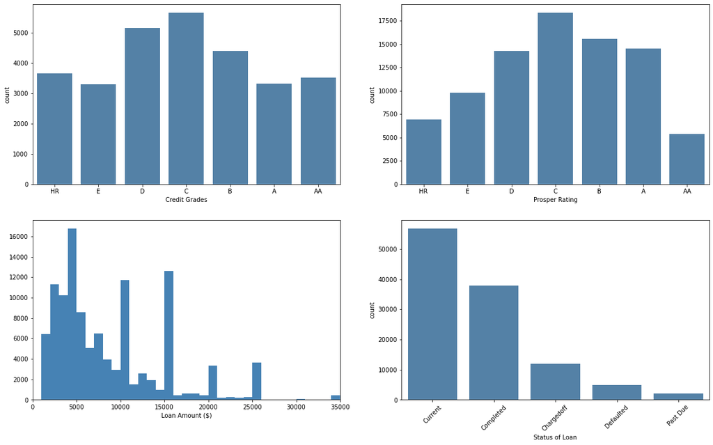

```python
#going to subplot 2,2 just to have a side by side look
plt.figure(figsize=(20,12))
plt.subplot(2,2,1)
sb.countplot(data=df,x='creditgrade',color='steelblue')
plt.xlabel('Credit Grades')
plt.subplot(2,2,2)
sb.countplot(data=df,x='prosperrating',color='steelblue')
plt.xlabel('Prosper Rating')
plt.subplot(2,2,3)
loan_bins = np.arange(0,df.loanoriginalamount.max()+100,1000)
plt.hist(df.loanoriginalamount,color='steelblue',bins=loan_bins)
plt.xlabel('Loan Amount ($)')
plt.xlim(0,35000)
plt.subplot(2,2,4)
sb.countplot(data=df,x='loanstatus',color='steelblue',
            order = df.loanstatus.value_counts().index)
plt.xticks(rotation=45)
plt.xlabel('Status of Loan');
```

These 4 plots should get us started with a feeling of how to approach our questions for the remainder of the data available to us.

The top 2 bar charts show us the distribution according to grades (Credit and Prosper), ordered by worst to best grade. Both charts are unimodal and not so skewed, with more "middle" grades than anything else. Important to note that Credit Grades had an extra NC grading possibility which represented a very small group, it was added into the HR group. This distribution caught me a bit off guard, as i expected much less counts in the higher ranked grades.

Our histogram of Loan amounts is very Right-skewed, with multiple peaks that appear to be around the multiples of 5k, especially at the 5k, 10k and 15k marks. Bins were adjusted to $1k steps. The amount of loans over the 25k mark make me want to not use them further as they are clearly outliers.

Our final bar chart show us the count of Loans divided into their current Status. Ordered by Count Descending. The data was tidied up to group all the Past Due categories into one. Cancelled was removed (only had 5 cases) and FinalPaymentProgress was encorporated to current.

Next let's take a quick look at where our Borrowers come from.

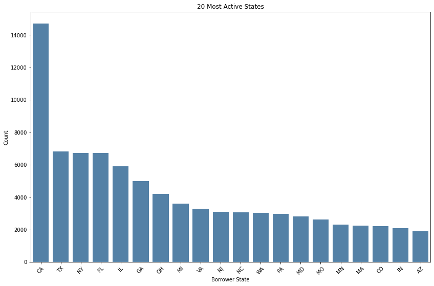

```python
plt.figure(figsize=(14,9))
sb.countplot(data=df,x=df.borrowerstate,order = df.borrowerstate.value_counts().head(20).index,color='steelblue')
plt.xticks(rotation=45)
plt.title('20 Most Active States')
plt.ylabel('Count')
plt.xlabel('Borrower State');
```

Here we gain a bit of insight that a large portion of the Borrower's come from CA, which makes sense since Prosper is a Californian based company. After that it seems to be spread out around the eastcoast but nothing special.

## Bivariate Exploration

To continue our observations into our dataset, I believe it would be interesting to take a better look at how the Status of our loans are divided.

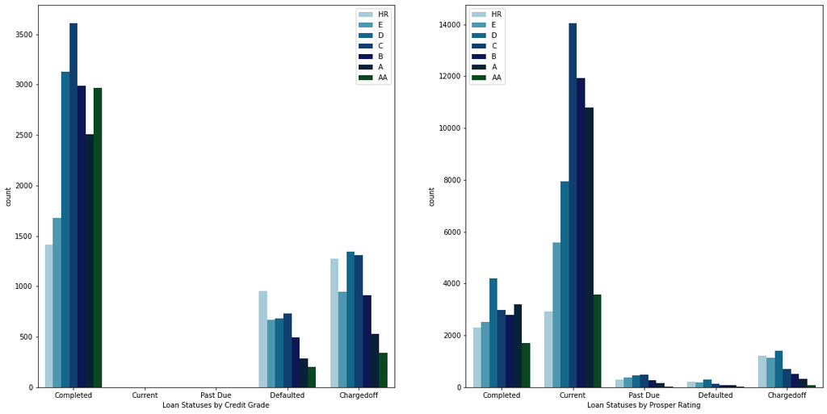

```python
plt.figure(figsize=(20,10))
plt.subplot(1,2,1)
ax = sb.countplot(data = df, x = 'loanstatus', hue = 'creditgrade',palette='ocean_r')
ax.legend(loc = 1)
ax.set_xlabel('Loan Statuses by Credit Grade')
plt.subplot(1,2,2)
ax = sb.countplot(data = df, x = 'loanstatus', hue = 'prosperrating',palette='ocean_r')
ax.legend(loc = 2)
ax.set_xlabel('Loan Statuses by Prosper Rating');
```

Our Right Plot, which uses the current Prosper Rating system, contains all our Current loans for the Dataset. Looking at only Current we see a sort of distribution that resembles our previous Univariate Countplot of Prosper Ratings. That is expected since we expect to see current loans to resemble a bit our distribution of Ratings. But when we look at all the other Status Categories, we notice a trend of very low AA, A and high HR,E counts for the "negative" outcome categories (i.e Defaulted and Charged Off). This is also expected, since consumers with lower credit ratings should theoretically have higher chances of defaulting.

We can also take a look at how the loan amount varies according to the Borrowers Rating.

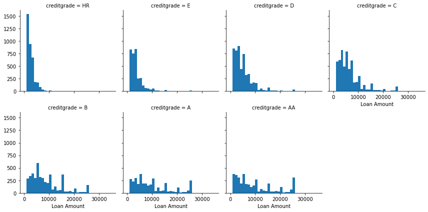

```python
#FacetGrid with Credit Grades
g = sb.FacetGrid(data = df,col='creditgrade',col_wrap=4, sharey=True)
g.map(plt.hist,'loanoriginalamount',bins=loan_bins) #reusing loan_bins from Loan amount Histogram
g.set_xlabels('Loan Amount');
```

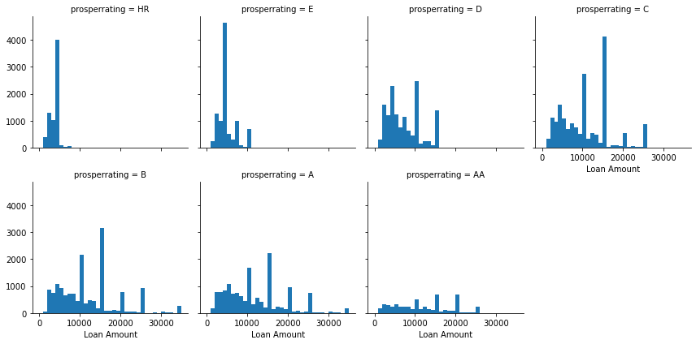

```python
#FacetGrid with Prosper Rating
g = sb.FacetGrid(data = df,col='prosperrating',col_wrap=4, sharey=True)
g.map(plt.hist,'loanoriginalamount',bins=loan_bins)
g.set_xlabels('Loan Amount');
```

Analyzing our FacetGrids, we can easily see a trend, lower grades concentrate their loans at or under the 10k mark, almost unanimously! The higher you go up the grade ladder, the more spaced out the loan amounts become. The Y axis has been shared for each FacetGrid so we can better compare each grade to the other.

It is common knowledge that a better Credit grade, or Prosper Rating in this case too, gives you access to better APR's. A set of Violin plots should allow us to take a good look into this.

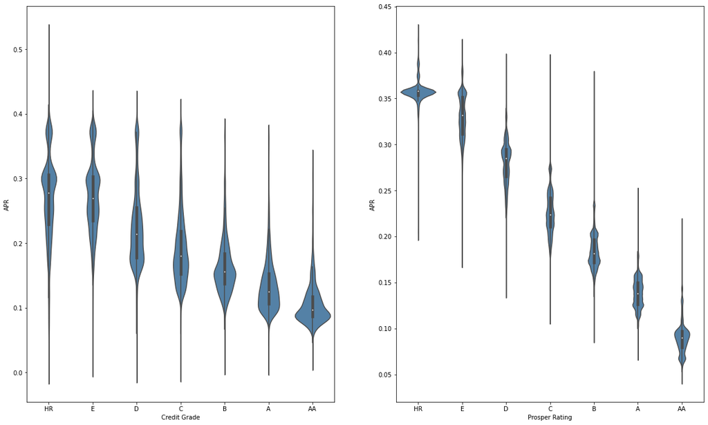

```python
plt.figure(figsize = [20, 12])

plt.subplot(1,2,1)
ax1 = sb.violinplot(data = df,x='creditgrade',y ='borrowerapr',color='steelblue')
ax1.set_xlabel('Credit Grade')
ax1.set_ylabel('APR')

plt.subplot(1,2,2)
ax2 = sb.violinplot(data=df,x='prosperrating',y='borrowerapr',color='steelblue')
ax2.set_xlabel('Prosper Rating')
ax2.set_ylabel('APR');
```

The Violin Plots bring us an Amazing insight of how the APR correlates to the Ratings. On Credit Grades the violins still had some tails/whiskers that balanced a bit the distribution, but on Prosper Ratings the APR obtained by HR rated clients was completly blown away by the APR obtained by AA rated.

If you were to guess the main factor that decides if a person can pay off a loan or not, Income has to be it. Afterall, a person making 1k dollars/month will find it much harder to pay off a 10k dollars Loan than a person who makes 20k dollars/month. From here on i shall start looking at Loans that have been closed already, either with a positive outcome (i.e Completed) or a negative outcome (i.e Chargedoff or Defaulted). Also, i shall filter out people who make over 20K dollars/month because they are not representing very well the rest of the dataset.

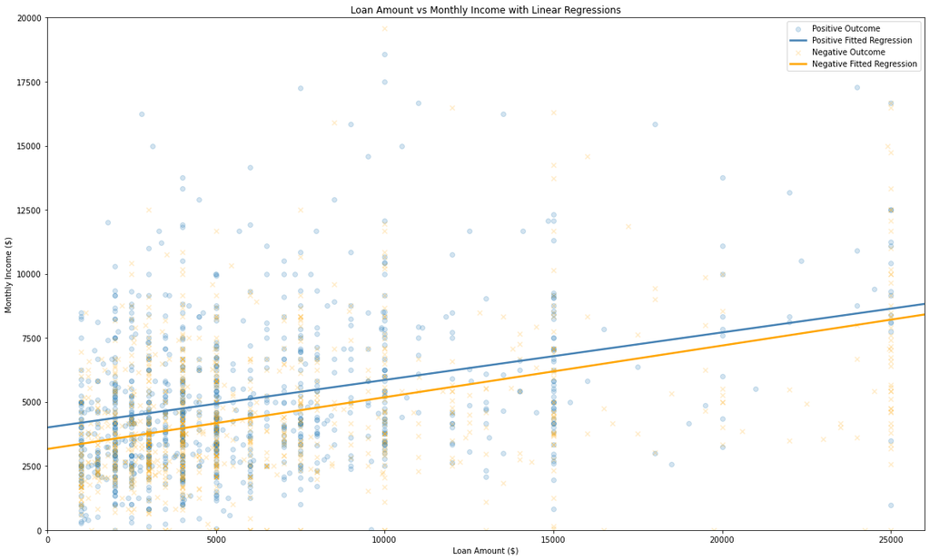

```python
#creating 2 df's for positive and negative outcome of closed loans, limiting to declared monthly income 20000, verifiable
positive_outcome = df.loc[(df.loanstatus=="Completed")&(df.statedmonthlyincome<20000)&(df.incomeverifiable==True)]
negative_outcome = df.loc[(df.loanstatus=="Chargedoff")|(df.loanstatus=="Defaulted")
                          &(df.statedmonthlyincome <20000)&(df.incomeverifiable==True)]

#Fitting a Linear Regression
xseq = np.linspace(0, 30000)
b, a = np.polyfit(positive_outcome.loanoriginalamount,positive_outcome.statedmonthlyincome, deg=1)
b2, a2 = np.polyfit(negative_outcome.loanoriginalamount,negative_outcome.statedmonthlyincome, deg=1)


#taking 1000 samples for plotting from each to not clutter too much, since they have 34k and 16k rows, respectively
positive_sample = positive_outcome.sample(1000)
negative_sample = negative_outcome.sample(1000)

#plotting in blue and orange instead of blue and red for colorblind visibility
plt.figure(figsize=(20,12))
plt.scatter(x='loanoriginalamount',y='statedmonthlyincome',alpha=0.2,data=positive_sample,marker='o')
plt.plot(xseq, a + b * xseq, color="steelblue", lw=2.5)
plt.scatter(x='loanoriginalamount',y='statedmonthlyincome',alpha=0.2,data=negative_sample,marker='x',color='orange')
plt.plot(xseq, a2 + b2 * xseq, color='orange', lw=2.5)
plt.xlabel("Loan Amount ($)")
plt.ylabel("Monthly Income ($)")
plt.legend(['Positive Outcome','Positive Fitted Regression','Negative Outcome','Negative Fitted Regression'])
plt.title('Loan Amount vs Monthly Income with Linear Regressions')
plt.ylim(0,20000)
plt.xlim(0,26000);
```

Although the Scatter part of the plot didn't relay much information, once fitted and plotted a linear regression we can observe 2 important pieces of information:

1. Positive correlation between Monthly income and Loan amount, which is expected but
2. The Fitted line for Negative Outcomes stays 'underneath' the Positive Outcomes fitted line. This shows us that for the same loan amount taken out, the Borrowers that didn't manage to pay the loan back in order had, on average, ALWAYS a lower verified Monthly Income. The lines should cross somewhere off the limits of the graph but that is outside of normal cases for our data.

Now, along with Monthly income, it should also be valid to look into the Debt to income ratio since people who have a lot of debt also should struggle to pay off their loans.

And for fun we shall see how these compare by our 20 most active States in the dataset

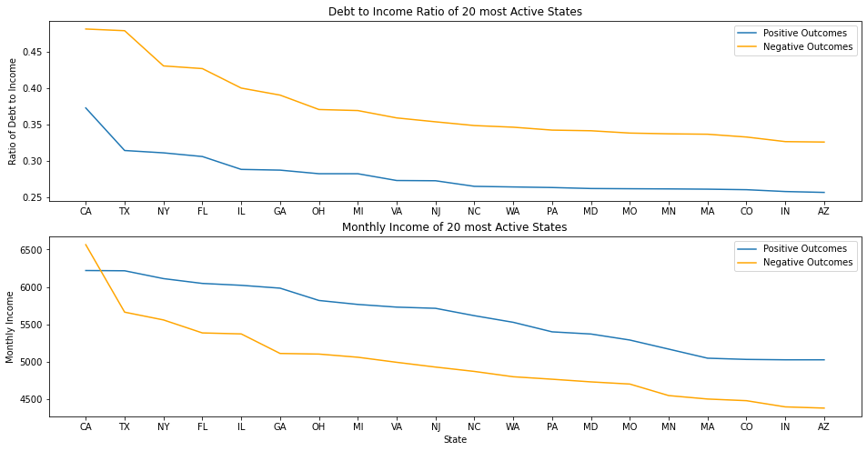

```python
#filtering 20 most active states
active_states = df.borrowerstate.value_counts().head(20).index

plt.figure(figsize=(16,8))

plt.subplot(2,1,1)

#plotting two lineplots over each other for positive and negative outcomes
ax1 = sb.lineplot(data=positive_outcome.groupby('borrowerstate').mean()['debttoincomeratio'].reset_index()\
            .sort_values(by='debttoincomeratio',ascending=False).head(20),
            x=active_states,y='debttoincomeratio')
plt.ylabel('Ratio of Debt to Income')
plt.title('Debt to Income Ratio of 20 most Active States')


ax2 = sb.lineplot(data=negative_outcome.groupby('borrowerstate').mean()['debttoincomeratio'].reset_index()\
            .sort_values(by='debttoincomeratio',ascending=False).head(20),
            x=active_states,y='debttoincomeratio',color='orange')
plt.ylabel('Ratio of Debt to Income')
plt.legend(('Positive Outcomes','Negative Outcomes'))

plt.subplot(2,1,2)

#once again two lineplots, this time for monthly income
ax3 = sb.lineplot(data=positive_outcome.groupby('borrowerstate').mean()['statedmonthlyincome'].reset_index()\
            .sort_values(by='statedmonthlyincome',ascending=False).head(20),
            x=active_states,y='statedmonthlyincome')
plt.title('Monthly Income of 20 most Active States')

ax4 = sb.lineplot(data=negative_outcome.groupby('borrowerstate').mean()['statedmonthlyincome'].reset_index()\
            .sort_values(by='statedmonthlyincome',ascending=False).head(20),
            x=active_states,y='statedmonthlyincome',color='orange')
plt.xlabel('State')
plt.ylabel('Monthly Income')
plt.legend(('Positive Outcomes','Negative Outcomes'));
```

And here we see once again that, while looking at the borrowers from the 20 most active states, the individuals that Defaulted had much higher Debt to Income Ratios and, simultaneously, lower Monthly Income. Except for CA Monthly Income, every other case had positive outcome having higher income and lower debt to income ratio.

## Multivariate Exploration

So far we have noticed that a persons Monthly Income and Debt to income ratio influence if that person will pay off a loan or not, let's try to use some Scatter Matrix's to see if anything else looks like it correlates.

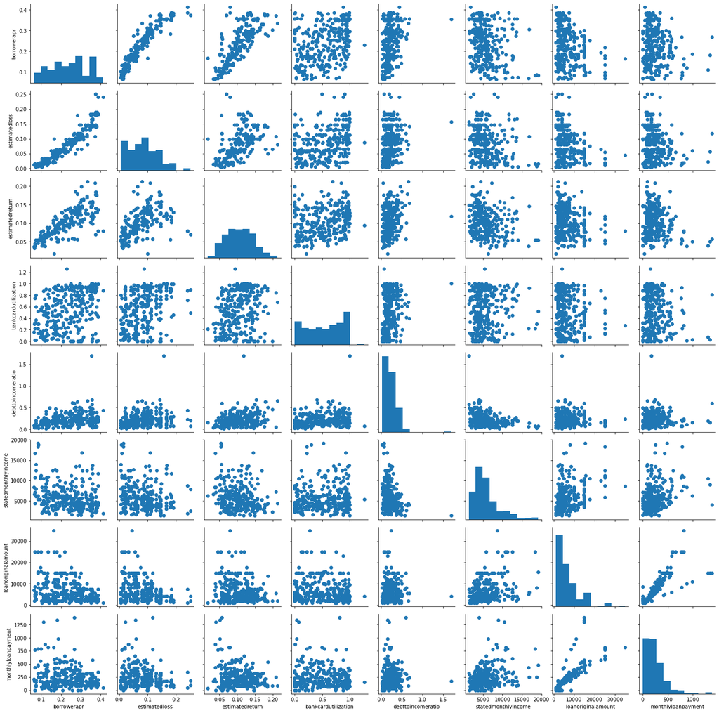

```python
#cleaning up a bit to remove some newly discovered outliers (after i ran my pairgrids a couple of times)
multi_pos = positive_outcome.loc[(positive_outcome.debttoincomeratio<2)&(positive_outcome.estimatedreturn>0)]
multi_neg = negative_outcome.loc[(negative_outcome.debttoincomeratio<2)]

#sampling only 300 to plot better
multi_pos = multi_pos.sample(300)
multi_neg = multi_neg.sample(300)

#list of possible interesting points to plot against
corr_list = ['borrowerapr','estimatedloss',
             'estimatedreturn','bankcardutilization',
             'debttoincomeratio','statedmonthlyincome',
            'loanoriginalamount','monthlyloanpayment']


g = sb.PairGrid(data=multi_pos,vars=corr_list)
g.map_diag(plt.hist)
g.map_offdiag(plt.scatter);
```

Eye catching correlations here are borrower APR with estimated loss and return and loan amount with monthly payment (which is trivial so we shall not explore this one further)

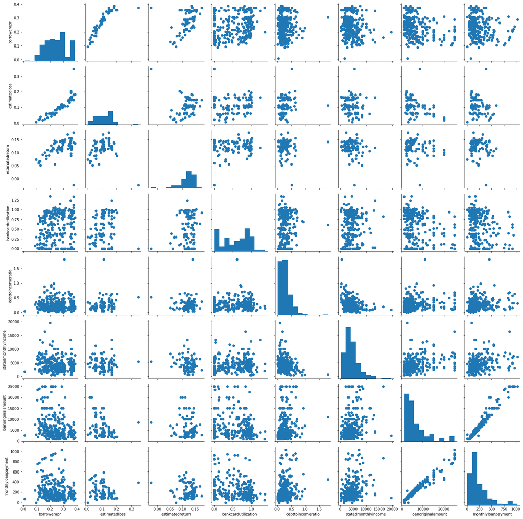

```python
g = sb.PairGrid(data=multi_neg,vars=corr_list)
g.map_diag(plt.hist)
g.map_offdiag(plt.scatter);
```

Important takeaway from the Negative Outcomes is quite the same as Positive Outcomes but with different scales. Time to plot those differences to try and see if we can uncover anything.

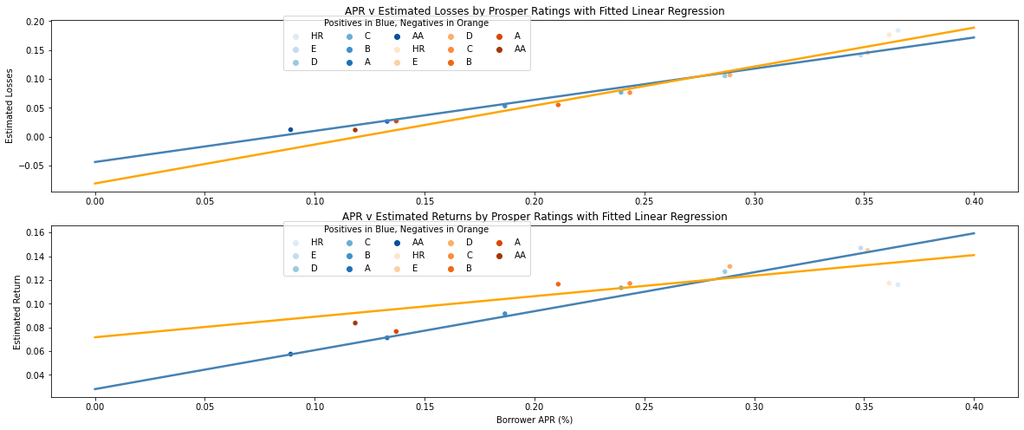

```python
#quick reminder that estimated loss is specific for columns that have Prosper Ratings and not Credit grade
#because of that, going to slice for only our values with ProsperRatings
multi_pos = multi_pos.loc[(multi_pos.prosperrating.notnull())]
multi_neg = multi_neg.loc[(multi_neg.prosperrating.notnull())]


#regressions
xseq2 = np.linspace(0, 0.4)
b3, a3 = np.polyfit(multi_pos.borrowerapr,multi_pos.estimatedloss, deg=1)
b4, a4 = np.polyfit(multi_neg.borrowerapr,multi_neg.estimatedloss, deg=1)
b5, a5 = np.polyfit(multi_pos.borrowerapr,multi_pos.estimatedreturn, deg=1)
b6, a6 = np.polyfit(multi_neg.borrowerapr,multi_neg.estimatedreturn, deg=1)

plt.figure(figsize=(20,8))

#plotting scatters with our mean values for each rating and regressions
plt.subplot(2,1,1)
sb.scatterplot(data=multi_pos.groupby('prosperrating').mean(),
               x='borrowerapr',y='estimatedloss',
               hue='prosperrating',palette='Blues')

sb.scatterplot(data=multi_neg.groupby('prosperrating').mean(),
               x='borrowerapr',y='estimatedloss',
               hue='prosperrating',palette='Oranges')

plt.plot(xseq2, a3 + b3 * xseq2, color="steelblue", lw=2.5)
plt.plot(xseq2, a4 + b4 * xseq2, color="orange", lw=2.5)


plt.ylabel("Estimated Losses")
plt.xlabel('')
plt.title("APR v Estimated Losses by Prosper Ratings with Fitted Linear Regression")
plt.legend(loc='best', bbox_to_anchor=(0.5, 1.05),
          ncol=5, fancybox=True,title="Positives in Blue, Negatives in Orange")

plt.subplot(2,1,2)
sb.scatterplot(data=multi_pos.groupby('prosperrating').mean(),
            x='borrowerapr',y='estimatedreturn',
            hue='prosperrating',palette='Blues')

sb.scatterplot(data=multi_neg.groupby('prosperrating').mean(),
            x='borrowerapr',y='estimatedreturn',
            hue='prosperrating',palette='Oranges')

plt.plot(xseq2, a5 + b5 * xseq2, color="steelblue", lw=2.5)
plt.plot(xseq2, a6 + b6 * xseq2, color="orange", lw=2.5)

plt.legend(loc='best', bbox_to_anchor=(0.5, 1.05),
          ncol=5, fancybox=True,title="Positives in Blue, Negatives in Orange")
plt.xlabel("Borrower APR (%)")
plt.ylabel("Estimated Return")
plt.title("APR v Estimated Returns by Prosper Ratings with Fitted Linear Regression");
```

Here we can observe how our Estimated Returns and Losses correlate to the Borrower Apr. Our Regressions, fitted without considering the Prosper Ratings, fits extremely well for the middle ranges of Ratings and tells us that we can pretty much associate linearly our Losses and Returns with the APR without looking into the Prosper Rating. Since both here seem to correlate well with Borrower APR, i won't be using them in my final Model, just the Borrower APR.

## Multiple Variable Regression Model

Now that we took a look into what seems to correlate with what, time to try to create a function that shall predict the probability of a borrower having a positive or negative outcome with their loan. For this we shall use the data from Positive and Negative, assign a 1 for positive and 0 for negative, then train a multi variable regression and try to apply that to our data that has no outcome yet (i.e the loans are still open).

```python
#once again we shall limit to verifiable income and 20000/month, to remove most of the outliers
p_outcome_df = df.loc[(df.loanstatus=="Completed")&(df.statedmonthlyincome <20000)&(df.incomeverifiable==True)].copy()
n_outcome_df = df.loc[(df.loanstatus=="Chargedoff")|(df.loanstatus=="Defaulted")
                     &(df.statedmonthlyincome <20000)&(df.incomeverifiable==True)].copy()
no_outcome_df = df.loc[(df.loanstatus=="Current")|(df.loanstatus=="Past Due")
                      &(df.statedmonthlyincome <20000)&(df.incomeverifiable==True)].copy()

p_outcome_df['outcome'] = 1
n_outcome_df['outcome'] = 0
outcome_df = pd.merge(p_outcome_df,n_outcome_df,how='outer')

#dropping nulls so we can fit a regression
outcome_df = outcome_df[outcome_df.borrowerapr.notnull()]
outcome_df = outcome_df[outcome_df.debttoincomeratio.notnull()]
outcome_df = outcome_df[outcome_df.statedmonthlyincome.notnull()]
outcome_df = outcome_df[outcome_df.loanoriginalamount.notnull()]

y = outcome_df['outcome']
x = outcome_df[['borrowerapr','debttoincomeratio','statedmonthlyincome','loanoriginalamount']]

x = sm.add_constant(x) # adding a constant

model = sm.OLS(y, x).fit()
outcome_df.outcome = model.predict(x)
model.summary()
```

OLS Regression Results

| Dep. Variable: | outcome | R-squared: | 0.066 |
| --- | --- | --- | --- |
| Model: | OLS | Adj. R-squared: | 0.066 |
| Method: | Least Squares | F-statistic: | 884.0 |
| Date: | Tue, 13 Sep 2022 | Prob (F-statistic): | 0.00 |
| Time: | 08:08:01 | Log-Likelihood: | -30705. |
| No. Observations: | 50165 | AIC: | 6.142e+04 |
| Df Residuals: | 50160 | BIC: | 6.146e+04 |
| Df Model: | 4 |  |  |
| Covariance Type: | nonrobust |  |  |

|  | coef | std err | t | P>\|t\| | [0.025 | 0.975] |
| --- | --- | --- | --- | --- | --- | --- |
| const | 0.9670 | 0.007 | 136.397 | 0.000 | 0.953 | 0.981 |
| borrowerapr | -1.2503 | 0.024 | -53.197 | 0.000 | -1.296 | -1.204 |
| debttoincomeratio | -0.0345 | 0.004 | -9.438 | 0.000 | -0.042 | -0.027 |
| statedmonthlyincome | 1.18e-05 | 6.59e-07 | 17.915 | 0.000 | 1.05e-05 | 1.31e-05 |
| loanoriginalamount | -8.049e-06 | 4.13e-07 | -19.500 | 0.000 | -8.86e-06 | -7.24e-06 |

| Omnibus: | 27430.736 | Durbin-Watson: | 0.133 |
| --- | --- | --- | --- |
| Prob(Omnibus): | 0.000 | Jarque-Bera (JB): | 7189.951 |
| Skew: | -0.739 | Prob(JB): | 0.00 |
| Kurtosis: | 1.879 | Cond. No. | 1.16e+05 |

Notes:  
[1] Standard Errors assume that the covariance matrix of the errors is correctly specified.  
[2] The condition number is large, 1.16e+05. This might indicate that there are  
strong multicollinearity or other numerical problems.

Quick reminder, again, that we are talking about thousands of stated monthly income and loan original amount, explaining why they appear to not have so much effect on our model (e-05 and e-06), if we had converted the values from those columns to 1000s then their coeficients would appear better. For now it is fine as is.

```python
#dropping nulls here as well to apply our model
no_outcome_df = no_outcome_df[no_outcome_df.borrowerapr.notnull()]
no_outcome_df = no_outcome_df[no_outcome_df.debttoincomeratio.notnull()]
no_outcome_df = no_outcome_df[no_outcome_df.statedmonthlyincome.notnull()]
no_outcome_df = no_outcome_df[no_outcome_df.loanoriginalamount.notnull()]

no_outcome_df['outcome'] = 0
x=no_outcome_df[['borrowerapr','debttoincomeratio','statedmonthlyincome','loanoriginalamount']]
x = sm.add_constant(x)

no_outcome_df.outcome = model.predict(x)

no_outcome_df.outcome.head(20)
```

```
1     0.802350
3     0.758633
4     0.642645
5     0.739328
6     0.570147
7     0.618533
8     0.821952
9     0.821952
10    0.599360
12    0.732458
13    0.800061
14    0.786133
16    0.643051
18    0.755106
19    0.627335
20    0.699192
22    0.176602
24    0.708535
25    0.635614
28    0.671454
Name: outcome, dtype: float64
```

To check how well our model fit, lets compare our mean from "no outcome df" column "outcome" (remembering that closer to 1 means a greater chance of having a positive outcome) to the length of Positive outcomes / Positive + Negative outcomes.

```python
no_outcome_df.outcome.mean(), len(p_outcome_df)/(len(p_outcome_df)+len(n_outcome_df))
```

```
(0.6784200384055366, 0.6755063242026849)
```

## Conclusions

Through our visualizations we were able to identify the distribution between Credit Grades and Prosper Ratings, along with the typical Loan amount and identified our demographic. Then we saw how the Loan amount was different according to said Grades and Ratings, along with the obtained APR. Diggin further we discovered the correlation between Monthly income and Debt to Income Ratio with the scenarios of Positive or Negative outcomes for the Loans, along with a general look at how Loan amount and Monthly Income faced off head to head.

Final exports to use in Part 2:

```python
df.to_csv('clean_copy.csv')
positive_outcome.to_csv('positive_outcome.csv')
positive_sample.to_csv('positive_sample.csv')
negative_outcome.to_csv('negative_outcome.csv')
negative_sample.to_csv('negative_sample.csv')
outcome_df.to_csv('predictor.csv')
no_outcome_df.to_csv('prediction.csv')
```